# The Impact of Severe Weather Events on Public Health and Economy

freestander

Friday, May 22, 2015

# Synopsis

The analysis shows the impact of the events to both public health and economic for communities based on NOAA storm data between 1950 and 2011. Tornado ranks the most dangerous weather event with regard to fatalities and excessive heat ranks the second. Tornado, tstm wind, and flood are top three causes for injuries. Flash flood and thunderstorm winds rank the first and second in terms of property damages. The largest crop damages are caused by drought, flood and river flood, in descending order.

# Data Processing

The NOAA storm database is a csv (comma separated value) file compressed in “bz2”" format. We load the data into R using read.csv() function. There is also some documentation of the database available. We use the “cache = TRUE” option in the data processing step since it is quite time consuming.

```r
# set the working directory (user specific)
setwd("C://Users//Qi-Desktop//Documents//RProjects//Coursera//Reproducible_Research//Project_2")
# read the NOAA storm data into R
NOAA_Storm <- read.csv(bzfile("data/repdata-data-StormData.csv.bz2"))
```

There is also some extra data processing steps to clean up the field “EVTYPE”, e.g., converting to lower cases and replacing some special characters with blank.

```r
# change the storm event type to lower case
NOAA_Storm$EVTYPE <- tolower(NOAA_Storm$EVTYPE)
# replace some special characters with "blank""
NOAA_Storm$EVTYPE <- gsub("[[:blank:][:punct:]+]", " ", NOAA_Storm$EVTYPE)
```

The property damage is represented with “PROPDMG” in dollars and the exponent “PROPDMGEXP”. Similarly, the crop damage is represented with “CROPDMG”" and “CROPDMGEXP”. We need to convert them into numeric values for ranking purposes.

```r
# exponential transformation function
# h(hundred) -> 2, k(thousand) -> 3, m(million) -> 6 , b(billion) -> 9
exp_transform <- function(e) {
    if (e %in% c('h', 'H'))
        return(2)
    else if (e %in% c('k', 'K'))
        return(3)
    else if (e %in% c('m', 'M'))
        return(6)
    else if (e %in% c('b', 'B'))
        return(9)
    else if (!is.na(as.numeric(e)))
        return(as.numeric(e))
    else if (e %in% c('', '-', '?', '+'))
        return(0)
    else {
        stop("Invalid value")
    }
}
```

```r
# compute the property damage by converting the expoential funtions to numeric values
property_damange_exp <- sapply(NOAA_Storm$PROPDMGEXP, FUN=exp_transform)
NOAA_Storm$property_damage <- NOAA_Storm$PROPDMG * (10^property_damange_exp)
# compute the crop damage by converting the expoential funtions to numeric values
crop_damage_exp <- sapply(NOAA_Storm$CROPDMGEXP, FUN=exp_transform)
NOAA_Storm$crop_damage <- NOAA_Storm$CROPDMG * (10^crop_damage_exp)
```

# Events with respect to Population Health

This section ranks the events with respect to the number of fatalities and injuries.

```r
library(plyr)
# sum up the fatalities and injuries for different type of events
health_events <- ddply(NOAA_Storm, .(EVTYPE), summarize, fatalities = sum(FATALITIES), injuries = sum(INJURIES))
# sort the events with fatalities in descending order
fatal_rank <- health_events[order(health_events$fatalities, decreasing = T), ]
# sort the events with injuries in descending order
injury_rank <- health_events[order(health_events$injuries, decreasing = T), ]
```

The following code shows the top ten events that have the most fatalities.

```r
# show the top 10 events that have the most fatalities
fatal_top_10 <- fatal_rank[1:10, c("EVTYPE", "fatalities")]
fatal_top_10
```

```
##             EVTYPE fatalities
## 741        tornado       5633
## 116 excessive heat       1903
## 138    flash flood        978
## 240           heat        937
## 410      lightning        816
## 762      tstm wind        504
## 154          flood        470
## 515    rip current        368
## 314      high wind        248
## 19       avalanche        224
```

The following code shows the top ten events that have the most injuries.

```r
# show the top 10 events that have the most injuries
injury_top_10 <- injury_rank[1:10, c("EVTYPE", "injuries")]
injury_top_10
```

```
##                EVTYPE injuries
## 741           tornado    91346
## 762         tstm wind     6957
## 154             flood     6789
## 116    excessive heat     6525
## 410         lightning     5230
## 240              heat     2100
## 382         ice storm     1975
## 138       flash flood     1777
## 671 thunderstorm wind     1488
## 209              hail     1361
```

# Events with respect to Economic Consequences

This section ranks the events with respect to the economic consequences.

```r
library(plyr)
# Compute the economic loss for each event type
economy_loss <- ddply(NOAA_Storm, .(EVTYPE), summarize, property_damage = sum(property_damage), crop_damage = sum(crop_damage))
# sort the events with property damage in descending order
property_damage_rank <- economy_loss[order(economy_loss$property_damage, decreasing = T), ]
# sort the events with crop damage in descending order
crop_damage_rank <- economy_loss[order(economy_loss$crop_damage, decreasing = T), ]
```

The following code shows the top ten events that have the most severe property damage.

```r
# show the top 10 events that have the most property damage
property_damage_top_10 <- property_damage_rank[1:10, c("EVTYPE", "property_damage")]
property_damage_top_10
```

```
##                 EVTYPE property_damage
## 138        flash flood    6.820237e+13
## 697 thunderstorm winds    2.086532e+13
## 741            tornado    1.078951e+12
## 209               hail    3.157558e+11
## 410          lightning    1.729433e+11
## 154              flood    1.446577e+11
## 366  hurricane typhoon    6.930584e+10
## 166           flooding    5.920825e+10
## 585        storm surge    4.332354e+10
## 270         heavy snow    1.793259e+10
```

The following code shows the top ten events that have the most severe crop damage.

```r
# show the top 10 events that have the most crop damage
crop_damage_rank_top_10 <- crop_damage_rank[1:10, c("EVTYPE", "crop_damage")]
crop_damage_rank_top_10
```

```
##                EVTYPE crop_damage
## 84            drought 13972566000
## 154             flood  5661968450
## 519       river flood  5029459000
## 382         ice storm  5022113500
## 209              hail  3025974480
## 357         hurricane  2741910000
## 366 hurricane typhoon  2607872800
## 138       flash flood  1421317100
## 125      extreme cold  1312973000
## 185      frost freeze  1094186000
```

# Results

In terms of population health, we can see that the top three causes for fatalities are tornado, excessive heat, and flash flood. The top three causes for injuries are tornado, stsm wind, and flood. In terms of economic consequences, the top three causes for property damages are flash flood, thunderstorm winds, and tornado. The top three crop damages are drought, flood, and river flood.

Note that some extra efforts can be spent to further clean up the data. For example, tstm wind and thunderstorm wind may represent the same event, while flood, flooding, flash flood, and river flood may mean similar events that could be merged to derive more accurate conclusions.

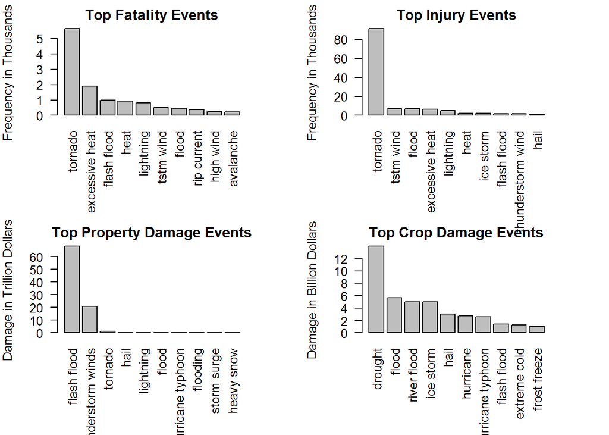

```r
# make a panel plot consisting of fatalities, injuries, property damages, and crop damages
library(lattice)

par(mfrow=c(2,2), mar = c(7, 4, 2, 4))

barplot(fatal_top_10$fatalities/1000,
        names.arg = fatal_top_10$EVTYPE,
        ylab = "Frequency in Thousands",
        main = "Top Fatality Events",
        las = 2)

barplot(injury_top_10$injuries/1000,
        names.arg = injury_top_10$EVTYPE,
        ylab = "Frequency in Thousands",
        main = "Top Injury Events",
        las = 2
        )

barplot(property_damage_top_10$property_damage/10^12,
        names.arg = property_damage_top_10$EVTYPE,
        ylab = "Damage in Trillion Dollars",
        main = "Top Property Damage Events",
        las = 2
        )

barplot(crop_damage_rank_top_10$crop_damage/10^9,
        names.arg = crop_damage_rank_top_10$EVTYPE,
        ylab = "Damage in Billion Dollars",
        main = "Top Crop Damage Events",
        las = 2
        )
```